# Movie Analysis

## Background

Terry is a father of a lovely family. He recently received a large sum of money and he and his wife decided to donate some of this money to a movie production company, becuase they are advant movie goers. Terry asked sent in a request to figure out which company made the most holesome movies. The question posed, is out of Universal Studios, Paramount Pictures, Warner Bros., Walt Disney Pictures, and Fox Studio, which company made the most PG movies.

### Data

After consulting with Terry, we removed all companies except for the Top 5 which he had selected. Following that we removed all ratings other than G, PG, PG-13, and R. This was to help us refine the data which we were analyizing.

```r
datatable(rat1[,c("company", "rating", "genre", "country")], options = list(lengthMenu = c(3,10,30)))
```

|  | company | rating | genre | country |
| --- | --- | --- | --- | --- |
| 1 | Paramount Pictures | PG-13 | Comedy | USA |
| 2 | Paramount Pictures | PG | Action | USA |
| 3 | Twentieth Century Fox Film Corporation | R | Action | USA |
| 4 | Walt Disney Pictures | PG | Adventure | USA |
| 5 | Paramount Pictures | PG-13 | Comedy | USA |
| 6 | Twentieth Century Fox Film Corporation | PG-13 | Comedy | USA |
| 7 | Twentieth Century Fox Film Corporation | PG-13 | Action | USA |
| 8 | Universal Pictures | PG | Action | USA |
| 9 | Paramount Pictures | PG | Adventure | USA |
| 10 | Paramount Pictures | PG-13 | Action | USA |

[output cut: 1151 more lines]

## Analysis

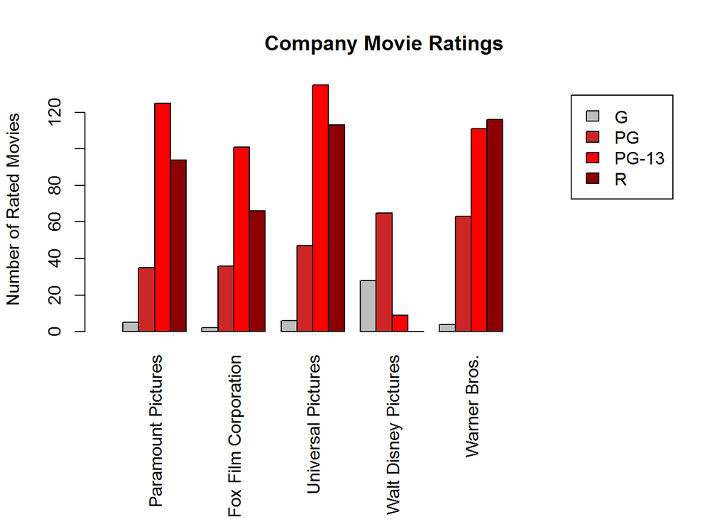

```r
topcomp <- subset(movies2, company == "Twentieth Century Fox Film Corporation" | company == "Walt Disney Pictures" | company == "Paramount Pictures" | company == "Warner Bros." | company == "Universal Pictures")

rat1 <- subset(topcomp, rating == "G" | rating == "PG" | rating == "PG-13" | rating == "R")

op <- par(mar=c(8.8,4,4,2)+ 0.1)
counts <- table(rat1$rating, rat1$company)
x <- barplot(counts, beside = TRUE, legend.text = c("G", "PG", "PG-13", "R"), las = 3, xlim = c(0,35), col = c("grey","firebrick3","red", "darkred"), main = "Company Movie Ratings", ylab = "Number of Rated Movies")
```

```r
par(op)
```

The above graph displayes the 5 top compnies selected, and the amount of G, PG, PG-13, and R rated movie they have made. Below is a table displaying the values as well.

```r
pander(counts, use.hyphening = TRUE, split.cells = c(10, 10, 10, 10, 10, 10, 10), justify = "center")
```

|  | Paramount Pictures | Twentieth Century Fox Film Corporation | Universal Pictures | Walt Disney Pictures | Warner Bros. |
| --- | --- | --- | --- | --- | --- |
| **G** | 5 | 2 | 6 | 28 | 4 |
| **PG** | 35 | 36 | 47 | 65 | 63 |
| **PG-13** | 125 | 101 | 135 | 9 | 111 |
| **R** | 94 | 66 | 113 | 0 | 116 |

## Interpretation

After a careful analysis of the data received we came to the conclusion that Walt Disney Pictures is the most wholesome company, and produced 65 PG rated movies, which is more than the other companies, however Warner Bros. came in a close second. with this information we believe Terry will be able to make the correct choice in whom they should donate.